# One Factor Randomized Block Design and Analysis

Cheng Peng

West Chester University

# 1 Introduction

One-Way Randomized Design is a fundamental experimental design in statistics where a single factor (independent variable) with two or more levels (groups) is studied to determine its effect on a dependent variable. The term “randomized” indicates that subjects or experimental units are randomly assigned to the different levels of the factor. This design is commonly analyzed using Analysis of Variance (ANOVA).

**Scenario**

A school district wants to evaluate the effectiveness of three different teaching methods (Traditional Lecture, Interactive Learning, and Flipped Classroom) on student performance in mathematics. The goal is to determine whether the choice of teaching method significantly impacts students’ test scores.

| Teaching Method | Test Scores (Dependent Variable) |
| --- | --- |
| Traditional Lecture | 75, 78, 72, 80, 74, 77, 76, 79, 73, 81, … |
| Interactive Learning | 82, 85, 80, 84, 83, 86, 81, 87, 82, 88, … |
| Flipped Classroom | 90, 88, 92, 89, 91, 87, 93, 90, 94, 89, … |

# 2 Key Terms and Data Layout

**Key Definitions**

- **Factor**: The independent variable being studied (e.g., type of fertilizer).
- **Levels**: The different values or categories of the factor (e.g., Fertilizer A, Fertilizer B, Fertilizer C).
- **Dependent Variable**: The outcome or response variable being measured (e.g., plant growth).
- **Balanced Design**: An equal number of observations in each level of the factor.
- **Unbalanced Design**: An unequal number of observations in each level of the factor.
- **ANOVA**: A statistical method to compare the means of two or more groups.

**Data Table Layout**

In a one-way randomized design, the data is typically organized as follows:

| Group (Level) | Observations (Dependent Variable) |
| --- | --- |
| Level 1 | $y_{11}, y_{12}, y_{13}, \cdots, y_{1n_1}$ |
| Level 2 | $y_{21}, y_{22}, y_{23}, \cdots, y_{2n_2}$ |
| $\vdots$ | $\vdots$ |
| Level k | $y_{k1}, y_{k2}, y_{k3}, \cdots, y_{kn_k}$ |

k: Number of levels (groups).

$y_{ij}$: The j-th observation in the i-th level.

**Balanced vs. Unbalanced Design**

Balanced Design: $n_1 = n_2 = \cdots = n_k$, for example $n_1 = n_2 = \cdots = n_k = 10$ observations in each of 3 groups.

Unbalanced Design: $n_i$ varies across groups. For example: 10 observations in Group 1, 8 in Group 2, and 12 in Group 3.

# 3 Analysis of Variance

## 3.1 Technical Formulas for ANOVA

The goal of ANOVA is to partition the total variability in the data into two components:

**Between-Group Variability**: Variability due to differences between group means.

**Within-Group Variability**: Variability due to differences within each group.

**Sum of Squares (SS)**

- Total Sum of Squares (SST):

- Between-Group Sum of Squares (SSB):

- Within-Group Sum of Squares (SSW):

- Degrees of Freedom (df)
  - $\text{df}_{\text{SST}} = N-1$, where $N = n_1 + n_2 + \cdots + n_k$.
  - $\text{df}_{\text{SSB}} = k-1$.
  - $\text{df}_{\text{SSW}} = N-k$.
- Mean Squares (MS)

The F-statistic is used to test the null hypothesis that all group means are equal.

## 3.2 A Numerical Example

**Problem**: A researcher wants to compare the effectiveness of three fertilizers (A, B, C) on plant growth. The data (in cm) is as follows:

| Fertilizer A | Fertilizer B | Fertilizer C |
| --- | --- | --- |
| 10 | 12 | 15 |
| 11 | 13 | 16 |
| 9 | 14 | 14 |
| 12 | 11 | 17 |

**Step 1**: Calculate Group Means and Overall Mean

**Step 2**: Calculate Sum of Squares

**Step 3: Calculate Degrees of Freedom**

- $\text{df}_{SST} = 12 - 1 = 11.$
- $\text{df}_{SSB} = 3 - 1 = 2.$
- $\text{df}_{SSW} = 12-3 = 9.$

**Step 4: Calculate Mean Squares**

**Step 5: Calculate F-Statistic**

**Step 6: Compare with Critical F-Value**

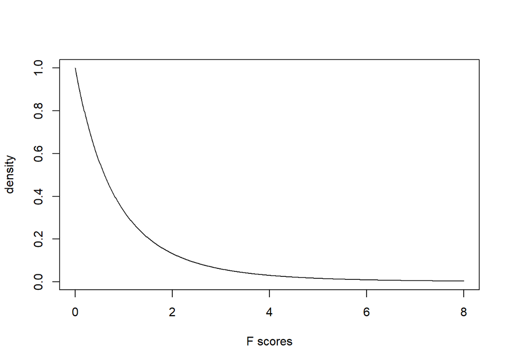

## 3.3 Assumptions for ANOVA

**Independence**: Observations are independent within and across groups.

**Normality**: The dependent variable is normally distributed within each group.

**Homogeneity of Variance**: The variance of the dependent variable is equal across all groups.

This example illustrates the application of one-way randomized design and ANOVA to compare group means, with detailed calculations and explanations of the underlying assumptions.

# 4 Use of Technology